# Performance and Salaries of NBA Players

December 1st, 2016

## Presentation Outline

- Project Description
- Source of Data
- Methodology
- EDA
- Results
- Conclusion

## Project Description

- Analyzing basketball players data from the NBA League in the 2015-2016 season

Our Aim: In the 2015-2016 season, how do the skills of a player relate to his salary?

## Source of Data

- Basketball Reference
- Roster, Total, and Salaries tables

[figure not shown]

## Methodology - Data Acquisition

- Two phases of webscraping
1. Get list of team abbreviations
2. Get the roster, salary, and totals tables via their IDs

## Methodology - Data Cleaning

- First we cleaned the data, then we merged the tables

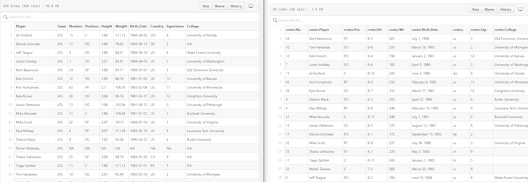

## EDA

- Split data into qualitative and quantitative
- Qualitative - used dplyr and frequency to analyze
- Quantitative - used summary() to get a summary of statistics

## Data Analysis - EFF

- \[\text{EFF} = \frac{|w_{1}|x_{1}}{\sigma_{1}} + ... + \frac{|w_{8}|x_{8}}{\sigma_{8}}\] where \(x_{i} = \frac{\text{ basic individual statistics}}{Game Played (GP)}\)

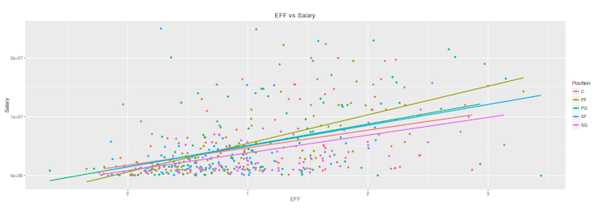

Correlation betweeen EFF vs Salary

## Data Analysis - Salary Aggregates

- Aggregated salary data by team

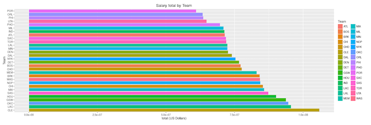

## Shiny Apps:

- Check out our nifty apps:
1. Team Salaries app - https://stat133.shinyapps.io/team-salaries/
2. Statistic Salaries app - https://stat133.shinyapps.io/stat-salaries/

## Conclusions

- While there is a positive correlation between EFF and salary, it is only moderate
- Our results can help managers better decide salaries for recruits
- We hypothesize that, in general, the salary is highly correlated with the number of wins that players bring in to the team